# circunferencia_tierra

```python
%matplotlib inline
%import_all
```

El radio de la Tierra es

```python
R_earth = constants.R_earth.to(u.km)
R_earth
```

$6378.1 \; \mathrm{km}$

Por lo tanto el perimetro de la Tierra es

```python
P_earth = 2 * np.pi * R_earth
P_earth
```

$40074.784 \; \mathrm{km}$

Aqui calculamos el angulo que subtiende la porcion de la superficie terrestre entre el observador y el horizonte del observador, dada su altura

```python
def curvatura(altura):
    return np.arccos(R_earth / (R_earth+altura)).to(u.deg)
```

Una funcion que calcula la distancia al horizonte dada la altura de observacion

```python
def horizonte(altura):
    return np.sin(curvatura(altura)) * (R_earth+altura)
```

## Desde un avion comercial

Por ejemplo, a una altura $h=10$ km (la altura de un avion comercial), el horizonte se ve a unos

```python
h = 10 * u.km
dh = horizonte(h)
dh
```

$357.29819 \; \mathrm{km}$

que subtiende un angulo alrededor del centro terrestre de

```python
angulo = curvatura(h)
angulo
```

$3.2063317 \; \mathrm{{}^{\circ}}$

equivalente a un 0.9% de la circunferencia completa.

Para visualizar ese arco, definimos las siguientes funciones:

```python
def arco(angulo):
    # largo de la cuerda
    c = 2 * R_earth * np.sin(angulo/2)
    x = np.linspace(-c/2, c/2, 20)
    y_curva = (R_earth**2 - x**2)**0.5
    return c, x, y_curva

def grafico(angulo, ancho=10, alto=3, recta=True):
    fig, ax = plt.subplots(figsize=(ancho,alto))
    c, x, y_curva = arco(angulo)
    ax.plot(x, y_curva, label='Arco de {0:.1f} grados'.format(angulo.value))
    if recta:
        y_recta = y_curva.mean() * np.ones(x.size)
        ax.plot(x, y_recta, label='Linea recta')
        ax.legend(loc='upper center')
    ax.set_xlim(-c.value/2, c.value/2)
    ax.set_ylim((R_earth-alto/ancho*c/2).value, (R_earth+alto/ancho*c/2).value)
    ax.axis('off');
    return
```

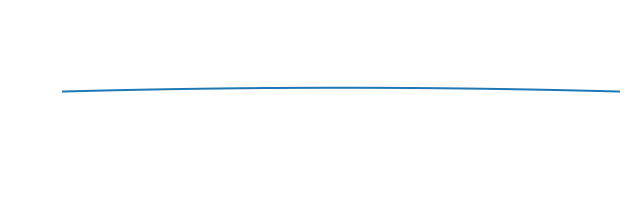

```python
grafico(angulo, recta=False)
```

Al mirar la linea azul por si sola es muy dificil discernir que no se trata de una linea recta. A esto hay que agregarle que la atmosfera hace que el horizonte no se vea bien definido. No es ninguna sorpresa que el horizonte parezca recto desde un avion comercial.

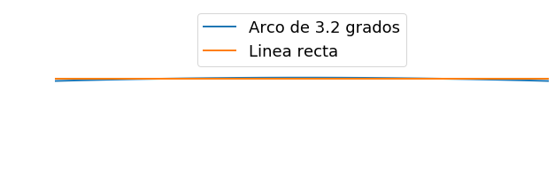

```python
grafico(angulo, recta=True)
```

Solo al agregar la linea recta como referencia queda claro que la linea azul es apenas curva. Esa es la diferencia que buscamos en el horizonte.

## Desde la Estacion Espacial Internacional (ISS)

Mientras que desde la estacion espacial internacional, a una altura de unos 400 km sobre la superficie de la Tierra, la distancia al horizonte es

```python
altura_iss = 400 * u.km
dh_iss = horizonte(altura_iss)
dh_iss
```

$2294.0096 \; \mathrm{km}$

que subtiende un angulo de

```python
angulo_iss = curvatura(altura_iss)
angulo_iss
```

$19.782123 \; \mathrm{{}^{\circ}}$

cuya diferencia con una linea recta se ve mas o menos asi:

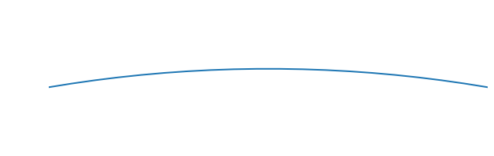

```python
grafico(angulo_iss, recta=False)
```

Incluso sin la referencia de una linea recta, queda claro que la linea es curva. Agregando la linea recta de referencia se aprecia cuanto mas curva se ve la Tierra desde la estacion espacial internacional comparado con un avion comercial en vuelo.

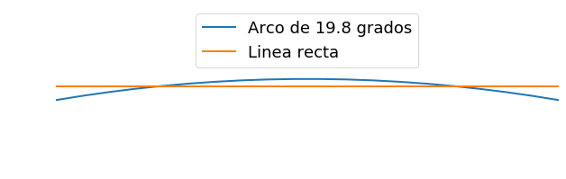

```python
grafico(angulo_iss)
```